# L24 LAB 16 (MD)

AnaGSanjuanM

2023-02-22

Laboratorio - Análisis de Redes en R - Indicadores básicos globales

———————–LABORATORIO 16———————

———–Alumna: Ana Grisel Sanjuan Merida————–

Corremos la librería de EconGeo

```r
library(EconGeo)
```

Cargamos nuestra Data. Es una lista de aristas, por ello se llama EL

Interacciones de los personajes de Los Miserables

```r
EL = read.csv("https://raw.githubusercontent.com/PABalland/ON/master/lesmis-el.csv")
```

Ver encabezado

```r
head(EL)
```

```
##     Character1  Character2 Weight
## 1 Gillenormand JeanValjean      2
## 2      Zephine   Listolier      3
## 3         Joly     Feuilly      5
## 4       Brevet       Judge      2
## 5   Bamatabois JeanValjean      2
## 6     Gavroche JeanValjean      1
```

Transformar dataframe a matriz de adyacencias

```r
MM <- get.matrix(EL)
```

Es una red no dirigida porque la matriz de adyacencias es simétrica

Twitter es un ejemplo de red dirigida porque puedo estar siguiendo a tal persona pero ella no me sigue.

Facebook es un ejemplo de red NO dirigida porque al enviar una solicitud de amsitad, dicha persona aceptará y seremos amigas ambas (es bidireccional).

Grafiquemos

Llamamos a la librería

```r
library(igraph)
```

Llamamos al objeto gráfico g. Con una gráfica que provenga del dataframe y los datos de EL. La red no es dirigida (es bidireccional) por lo que directed=FALSE

```r
g <- graph_from_data_frame(d=EL, directed = FALSE)
```

Para visualizar objeto gráfico g

```r
g
```

```
## IGRAPH 30dfaff UN-- 77 508 --
## + attr: name (v/c), Weight (e/n)
## + edges from 30dfaff (vertex names):
##  [1] Gillenormand   --JeanValjean
##  [2] Zephine        --Listolier
##  [3] Joly           --Feuilly
##  [4] Brevet         --Judge
##  [5] Bamatabois     --JeanValjean
##  [6] Gavroche       --JeanValjean
##  [7] MadameHucheloup--Courfeyrac
##  [8] Gavroche       --Javert
## + ... omitted several edges
```

Para generar el plot

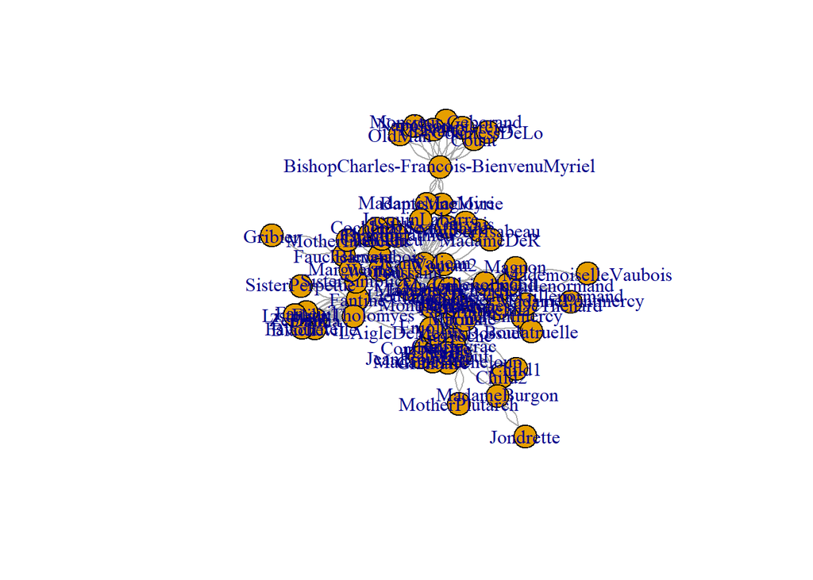

```r
plot(g)
```

Interacciones entre personajes sin considerar el peso, solo identificar quién se relaciona con quién

```r
EL$Weight = NULL
```

Para visualizar

```r
head(EL)
```

```
##     Character1  Character2
## 1 Gillenormand JeanValjean
## 2      Zephine   Listolier
## 3         Joly     Feuilly
## 4       Brevet       Judge
## 5   Bamatabois JeanValjean
## 6     Gavroche JeanValjean
```

Aparece el listado sin el peso, solo su interacción

Instalamos netword3

install.packages(“networkD3”)

Llamamos a la librería

```r
library(networkD3)
```

Visualización que busca la estructura/layout más adecuada dependiendo los datos

```r
simpleNetwork(EL)
```

[interactive chart not shown]

—————————-FIN DE LABORATORIO 16————————–